# MGMT gene methylation: TCGA data analysis

O. Celiku

May 21 12:52:53 PM 2025

The input files were generated based ond downloaded files from Xena browser and filtering for samples that had relevant information:

- mRNA expression, filtered to MGMT only: tcga_RSEM_Hugo_norm_count.gz”: mRNA expression
- Methylation, filtered to probes associated with MGMT (based on Illumina Methylation 450k array probe annotations obtained using methylationARrayAnalysis library): jhu-usc.edu_PANCAN_HumanMethylation450.betaValue_whitelisted.tsv.xena
- Phenotype: TCGA_phenotype_denseDataOnlyDownload.tsv.gz
- Mutation: mc3.v0.2.8.PUBLIC.nonsilentGene.xena.gz

### Descriptive landscape of pan-cancer, including glioma

First some overview of the landscape using most varied samples for each cancer type; showing here for top 50 most varied samples (excluding those that fall outside 95% quantile of sd), roughly grouping the probes by region with any probes annotated as promoter considered as promoter (despite CpG island status) and the rest as body.

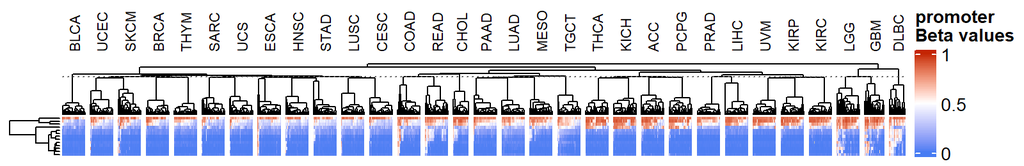

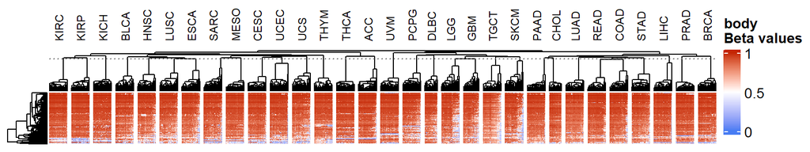

### Cohort specific associations of region methylation with mRNA

Here we compute the aggregated methylation levels per region per sample first aggregating probes by smaller regulatory regions and then promoter versus body:

- For promoter values we aggregate the values that are promoter associated per annotations, as well as fall on CpG islands.
- For body we use all values that are not promoter associated.

We consider pan-cancer excluding glioma cohort separately; as well as the glioma cohorts split by IDH mutation status.

First correlation analyses, as well as linear regression of association of mRNA expression with promoter and body methylation, considering models with and without interaction.

#### Non-glioma

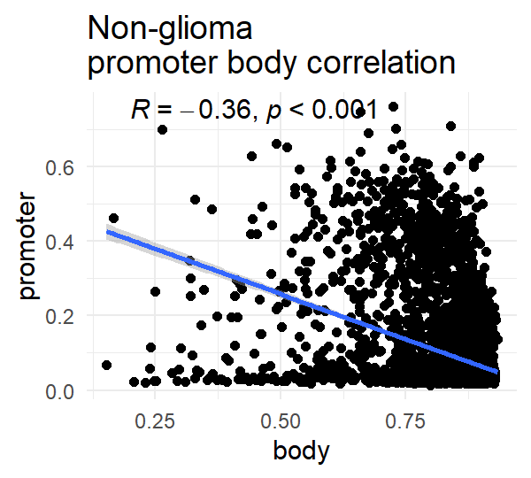

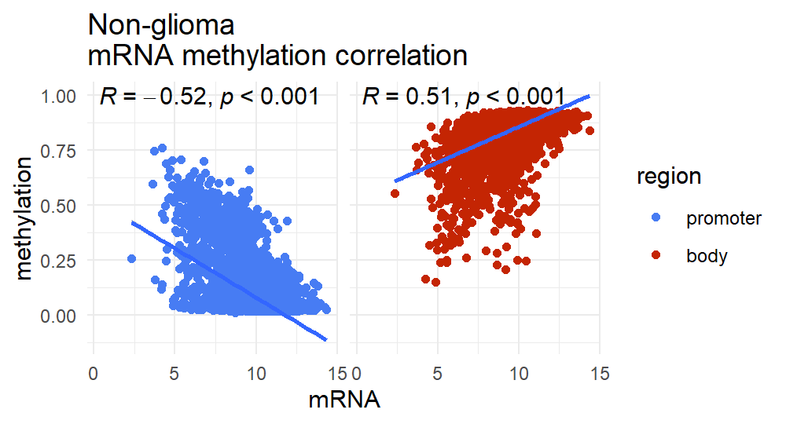

Regression model without interaction; non-glioma:

```
##
## Call:
## lm(formula = mRNA ~ promoter + body, data = wide %>% filter(cohort ==
##     "non-glioma"))
##
## Residuals:
##     Min      1Q  Median      3Q     Max
## -5.1359 -0.5987 -0.0505  0.5478  4.3128
##
## Coefficients:
##             Estimate Std. Error t value Pr(>|t|)
## (Intercept)   5.2457     0.1381   37.98   <2e-16 ***
## promoter     -4.4954     0.1161  -38.72   <2e-16 ***
## body          5.8609     0.1570   37.33   <2e-16 ***
## ---
## Signif. codes:  0 '***' 0.001 '**' 0.01 '*' 0.05 '.' 0.1 ' ' 1
##
## Residual standard error: 0.9841 on 7041 degrees of freedom
## Multiple R-squared:  0.3901, Adjusted R-squared:  0.3899
## F-statistic:  2252 on 2 and 7041 DF,  p-value: < 2.2e-16
```

Regression model with interaction; non-glioma:

```
##
## Call:
## lm(formula = mRNA ~ promoter * body, data = wide %>% filter(cohort ==
##     "non-glioma"))
##
## Residuals:
##     Min      1Q  Median      3Q     Max
## -5.1548 -0.6027 -0.0512  0.5423  4.3130
##
## Coefficients:
##               Estimate Std. Error t value Pr(>|t|)
## (Intercept)     5.5751     0.1772  31.457  < 2e-16 ***
## promoter       -6.7903     0.7828  -8.674  < 2e-16 ***
## body            5.4633     0.2064  26.466  < 2e-16 ***
## promoter:body   2.9363     0.9905   2.964  0.00304 **
## ---
## Signif. codes:  0 '***' 0.001 '**' 0.01 '*' 0.05 '.' 0.1 ' ' 1
##
## Residual standard error: 0.9836 on 7040 degrees of freedom
## Multiple R-squared:  0.3908, Adjusted R-squared:  0.3906
## F-statistic:  1506 on 3 and 7040 DF,  p-value: < 2.2e-16
```

#### Glioma IDH-wild-type

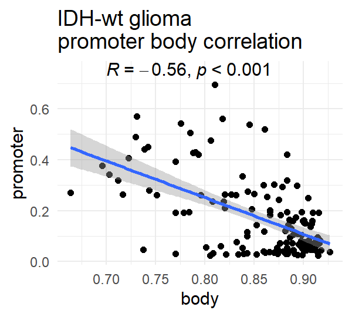

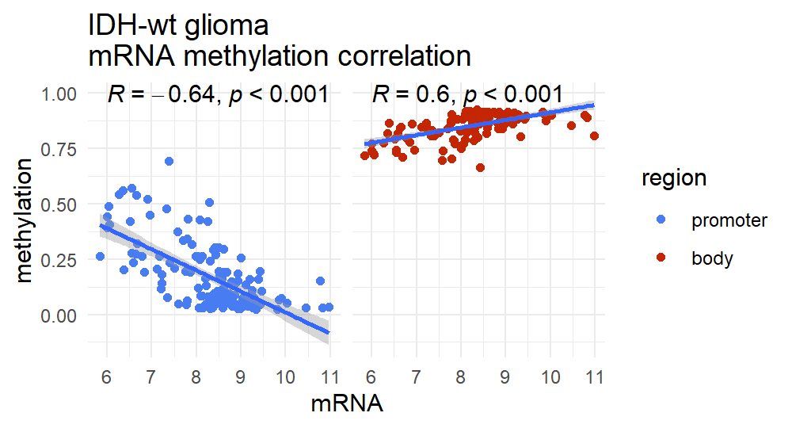

Regression model without interaction; IDH-wt glioma:

```
##
## Call:
## lm(formula = mRNA ~ promoter + body, data = wide %>% filter(cohort ==
##     "glioma IDHWT"))
##
## Residuals:
##     Min      1Q  Median      3Q     Max
## -1.8813 -0.4494  0.0190  0.3905  2.5474
##
## Coefficients:
##             Estimate Std. Error t value Pr(>|t|)
## (Intercept)   3.6766     1.1647   3.157  0.00198 **
## promoter     -3.0699     0.5061  -6.066 1.30e-08 ***
## body          6.0064     1.3017   4.614 9.23e-06 ***
## ---
## Signif. codes:  0 '***' 0.001 '**' 0.01 '*' 0.05 '.' 0.1 ' ' 1
##
## Residual standard error: 0.7323 on 132 degrees of freedom
## Multiple R-squared:  0.4961, Adjusted R-squared:  0.4885
## F-statistic: 64.99 on 2 and 132 DF,  p-value: < 2.2e-16
```

Regression model with interaction; IDH-wt glioma:

```
##
## Call:
## lm(formula = mRNA ~ promoter * body, data = wide %>% filter(cohort ==
##     "glioma IDHWT"))
##
## Residuals:
##     Min      1Q  Median      3Q     Max
## -1.8770 -0.4433  0.0206  0.3887  2.5551
##
## Coefficients:
##               Estimate Std. Error t value Pr(>|t|)
## (Intercept)      3.528      1.979   1.783  0.07691 .
## promoter        -2.411      7.106  -0.339  0.73498
## body             6.180      2.278   2.713  0.00756 **
## promoter:body   -0.796      8.560  -0.093  0.92606
## ---
## Signif. codes:  0 '***' 0.001 '**' 0.01 '*' 0.05 '.' 0.1 ' ' 1
##
## Residual standard error: 0.7351 on 131 degrees of freedom
## Multiple R-squared:  0.4962, Adjusted R-squared:  0.4846
## F-statistic:    43 on 3 and 131 DF,  p-value: < 2.2e-16
```

#### Glioma IDH-mutant

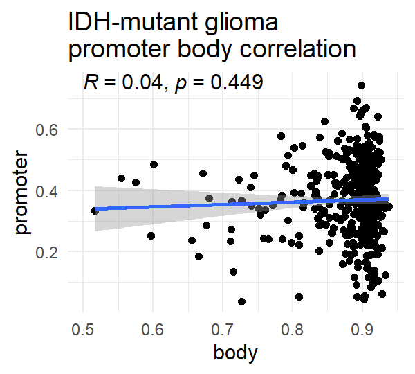

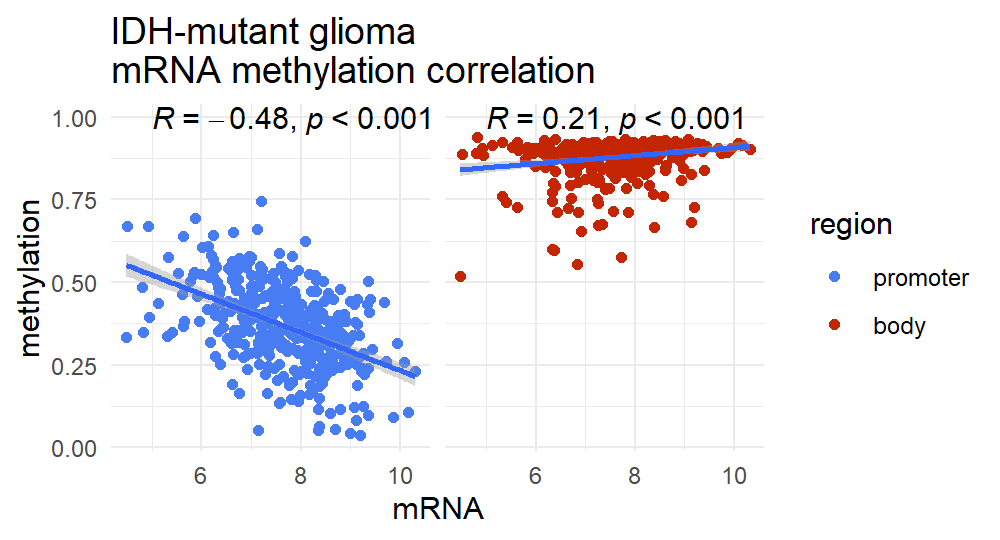

Regression model without interaction; IDH-mutant glioma:

```
##
## Call:
## lm(formula = mRNA ~ promoter + body, data = wide %>% filter(cohort ==
##     "glioma IDHMut"))
##
## Residuals:
##     Min      1Q  Median      3Q     Max
## -3.1612 -0.5698  0.0394  0.5789  2.2653
##
## Coefficients:
##             Estimate Std. Error t value Pr(>|t|)
## (Intercept)   5.7583     0.6421   8.968  < 2e-16 ***
## promoter     -4.0700     0.3505 -11.614  < 2e-16 ***
## body          3.8789     0.7191   5.394 1.17e-07 ***
## ---
## Signif. codes:  0 '***' 0.001 '**' 0.01 '*' 0.05 '.' 0.1 ' ' 1
##
## Residual standard error: 0.8667 on 406 degrees of freedom
## Multiple R-squared:  0.282,  Adjusted R-squared:  0.2785
## F-statistic: 79.75 on 2 and 406 DF,  p-value: < 2.2e-16
```

Regression model with interaction; IDH-mutant glioma:

```
##
## Call:
## lm(formula = mRNA ~ promoter * body, data = wide %>% filter(cohort ==
##     "glioma IDHMut"))
##
## Residuals:
##     Min      1Q  Median      3Q     Max
## -3.1637 -0.5685  0.0528  0.5800  2.2181
##
## Coefficients:
##               Estimate Std. Error t value Pr(>|t|)
## (Intercept)      1.837      2.111   0.870 0.384730
## promoter         7.206      5.793   1.244 0.214288
## body             8.323      2.389   3.484 0.000549 ***
## promoter:body  -12.770      6.549  -1.950 0.051876 .
## ---
## Signif. codes:  0 '***' 0.001 '**' 0.01 '*' 0.05 '.' 0.1 ' ' 1
##
## Residual standard error: 0.8638 on 405 degrees of freedom
## Multiple R-squared:  0.2887, Adjusted R-squared:  0.2834
## F-statistic:  54.8 on 3 and 405 DF,  p-value: < 2.2e-16
```